# GENE315 CNV lab - week 2

Mik Black

2 & 3 April 2025

## Overview

This week we will be doing three things:

- Continuing looking at the count data from last week, focusing on differences between the two loci (IRGM, FCGR) across the three populations (CEU, CHB, YRI).
- Looking at single nucleotide polymorphism (SNP) data from SNPs near the IRGM and FCGR3B genes.
- Combining the SNP and CNV data to investigate linkage disequilibrium (LD) in the three populations.

This document will walk through some simple analysis in R to accomplish the tasks above. There is also a markdown version of this document online which can be viewed in a browser (makes copying and pasting code easier):

https://github.com/mikblack/GENE315-CNVlab/blob/master/GENE315-CNV_lab-week2.md

**REMINDER: FOR YOUR ASSIGNMENT YOU WILL NEED TO ALTER THE CODE BELOW TO PERFORM A SIMILAR ANALYSIS FOR THE IRGM DATA AND THE RELEVANT SNP (rs13361189).**

## CNV - back to FCGR

Load the FCGR count data that we used last week:

```r
fcgrDat = read.csv('FCGR-counts.csv', row.names=1)
```

One of the tasks last week was to use the commands you had learned to loop through the first 20 plots of the FCGR data for the CEU population. Hopefully your code looked something like this (if not, this should give you a pretty good hint of what your code *should* look like):

```r
source('plotCNV.R')
par(ask=T)
for(i in 1:20){
  plotCNV( fcgrDat, colnames(fcgrDat)[i], "FCGR", truncate=TRUE)
  abline(h = median(fcgrDat[,i]), col='blue')
  abline(h = 1.5*median(fcgrDat[,i]), col='blue', lty=2)
  abline(h = 0.5*median(fcgrDat[,i]), col='blue', lty=2)
}
```

One of your tasks last week was to use this code to examine the FCGR region for the first 20 samples in the CEU population.  
The goal was to identify samples that exhibit CNV (i.e., do not have CN=2) for the FCGR3B gene (marked as “3B” on the plot).

This week we are looking at copy number is ALL the samples!

## Copy number calls

Luckily for you I went through all 310 samples and manually called (i.e., guesstimated) copy number for the region upstream of IRGM, and for the FCGR3B gene, based on the plots of the count data (yep, thats right - 310 samples, twice…)

These data are saved in the file `CNcalls.csv`. You can load them into R via:

```r
CNcalls = read.csv('CNcalls.csv')
```

View the first rows of the data via:

```r
head(CNcalls)
```

```
##    Sample Population IRGM_CN FCGR3B_CN
## 1 NA06984        CEU       2         2
## 2 NA06985        CEU       2         2
## 3 NA06986        CEU       1         2
## 4 NA06989        CEU       2         3
## 5 NA06994        CEU       2         2
## 6 NA07000        CEU       2         2
```

Have a look at the FCGR3B copy number calls for the first 20 samples - do they agree with the calls you made when you generated the 20 FCGR region plots above?

As for the count data, the first 99 rows relate to the CEU population, the next 103 relate to CHB and the final 108 are for YRI. We can investigate the relationship differences in FCGR3B copy number across populations via:

```r
fcgrTab = table(CNcalls[,"Population"], CNcalls[,"FCGR3B_CN"])
fcgrTab
```

```
##
##        0  1  2  3
##   CEU  0  7 83  9
##   CHB  0 12 71 20
##   YRI  2 18 83  5
```

The Chi-squared test can be used to determine whether the distribution of copy number is consistent across the three populations:

```r
chisq.test( fcgrTab )
```

```
##
##  Pearson's Chi-squared test
##
## data:  fcgrTab
## X-squared = 20.186, df = 6, p-value = 0.002566
```

As mentioned last week, it is more appropriate to use Fisher’s Exact Test when possible, as the Chi-squared test is an approximation. Here the results are similar:

```r
fisher.test( fcgrTab )
```

```
##
##  Fisher's Exact Test for Count Data
##
## data:  fcgrTab
## p-value = 0.002169
## alternative hypothesis: two.sided
```

The significant p-value indicates that copy nmber variation for FCGR3B does not occur at the same frequency across the three populations.

It is easiest to see this by converting the table data to proportions. Adding the “1” parameter ensures that the proporitions are specific to each row (population):

```r
options(digits=3)
prop.table( fcgrTab, 1)
```

```
##
##            0      1      2      3
##   CEU 0.0000 0.0707 0.8384 0.0909
##   CHB 0.0000 0.1165 0.6893 0.1942
##   YRI 0.0185 0.1667 0.7685 0.0463
```

We can also represent this information graphically:

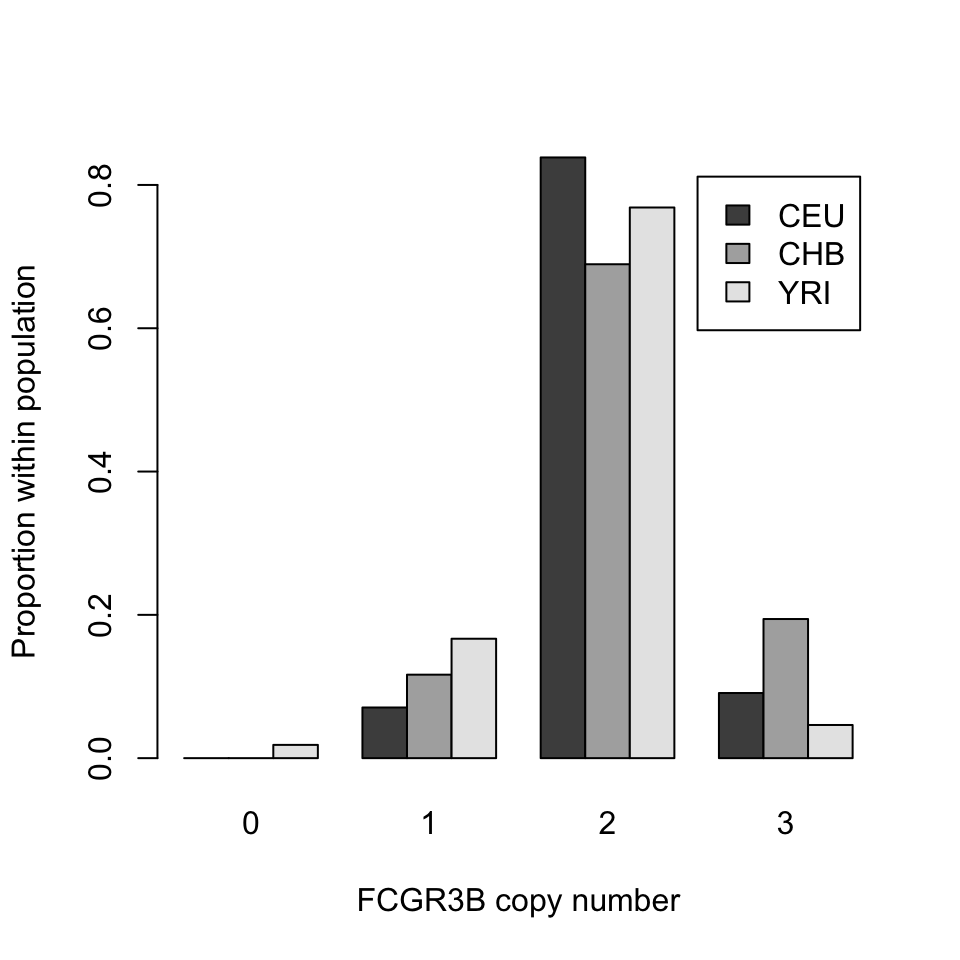

```r
barplot( prop.table( fcgrTab, 1), beside=TRUE, legend=TRUE,
         xlab="FCGR3B copy number", ylab= "Proportion within population")
```

## SNP data

These data were obtained from the ensembl website. Have a look at the 1000 Geneomes Project data for SNP `rs117435514` by searching for it at

http://www.ensembl.org/Homo_sapiens/

and then clicking on the “population genetics” link. This provides data on SNP frequency (and also per-sample genotype) across the populations. The data from this website was used to create SNP genotype files for the samples we are analysing in this lab.

The data for FCGR can be loaded as follows:

```r
fcgrSNP = read.csv('FCGR_rs117435514.csv')
```

Look at the first six rows:

```r
head(fcgrSNP)
```

```
##   X  Sample Population rs117435514
## 1 1 NA06984        CEU          AA
## 2 2 NA06985        CEU        <NA>
## 3 3 NA06986        CEU          AA
## 4 4 NA06989        CEU          AA
## 5 5 NA06994        CEU          AA
## 6 6 NA07000        CEU          AA
```

The distribution of SNP genotypes can be examined via:

```r
table( fcgrSNP[,"rs117435514"] )
```

```
##
##  AA  AG
## 236  28
```

which shows that most individuals have the AA genotype, and relatively few have the AG genotype (and none have the GG genotype). Also, note that some of the samples have missing genotype data for this SNP, denoted by `<NA>` in the output above.

These genotypes can also be viewed across population groups, which shows that most of the genotypic variation in this SNP occurs in the CHB population:

```r
table( fcgrSNP[,"Population"], fcgrSNP[,"rs117435514"] )
```

```
##
##       AA AG
##   CEU 84  0
##   CHB 71 24
##   YRI 81  4
```

The amount of missing data can be inferred from the table above, since there should be 99, 103 and 108 genotype values for the CEU, CHB and YRI populations respectively. Adding `useNA='always'` to the `table` command shows the missing data:

```r
table( fcgrSNP[,"Population"], fcgrSNP[,"rs117435514"] , useNA='always')
```

```
##
##        AA AG <NA>
##   CEU  84  0   15
##   CHB  71 24    8
##   YRI  81  4   23
##   <NA>  0  0    0
```

We can also represent the genotype proportions as a bar graph:

```r
fcgrSnpTab = table( fcgrSNP[,"Population"], fcgrSNP[,"rs117435514"] )
round( prop.table(fcgrSnpTab, 1), 3)
```

```
##
##          AA    AG
##   CEU 1.000 0.000
##   CHB 0.747 0.253
##   YRI 0.953 0.047
```

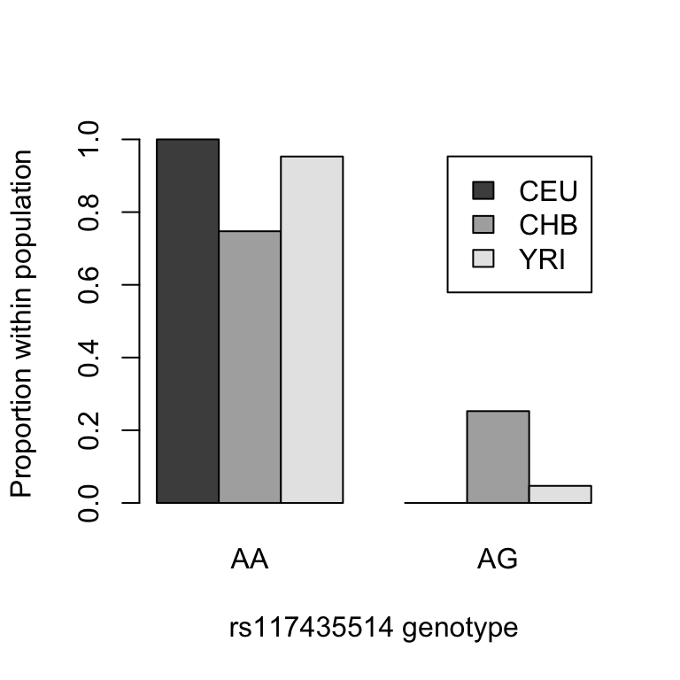

```r
barplot( prop.table(fcgrSnpTab, 1), beside=TRUE, legend=TRUE, xlab="rs117435514 genotype", ylab= "Proportion within population")
```

## TagSNPs - combining SNP and CNV data

If a specific SNP genotype is a associated with a change in copy number in a particular region, then that SNP can be said to *tag* that copy number variant. That is, an individual with that SNP genotype is more likely to also have altered copy number for that region.

We can investigate this at the FCGR locus by combining the copy number calls for FCGR3B with the genotype data for SNP rs117435514 (note that this works because I’ve made sure that all of the data are in the same order in each file):

```r
table( fcgrSNP[,"rs117435514"], CNcalls[,"FCGR3B_CN"], dnn=c("SNP","CopyNumber") )
```

```
##     CopyNumber
## SNP    0   1   2   3
##   AA   1  33 185  17
##   AG   0   0  14  14
```

The `dnn` parameter allows us to label the rows and columns of the table. We can look at just the CHB population as follows:

```r
table( fcgrSNP[,"rs117435514"], CNcalls[,"FCGR3B_CN"],  CNcalls[,"Population"] )[,,"CHB"]
```

```
##
##       0  1  2  3
##   AA  0 12 55  4
##   AG  0  0 10 14
```

Clearly individuals in the CHB population are more likely to have 3 copies of the FCGR3B gene if they have the AG genotype as compared to the AA genotype, but the *tagging* is not anywhere near perfect.

We can test to see if this association is statistically significant using Fisher’s Exact Test:

```r
fcgrCHBtab = table( fcgrSNP[,"rs117435514"], CNcalls[,"FCGR3B_CN"],  CNcalls[,"Population"] )[,,"CHB"]
fisher.test( fcgrCHBtab )
```

```
##
##  Fisher's Exact Test for Count Data
##
## data:  fcgrCHBtab
## p-value = 2e-07
## alternative hypothesis: two.sided
```

So, even though the SNP rs117435514 does not tag CNV at FCGR3B particularly well, the association is highly statistically significant (i.e., it is very unlikely that we would see a relationship this strong by chance).

## Assignment

### Week two questions:

Please include the following details in your document:

1. Load the IRGM copy number calls, and generate a table, a proportion table, and a barplot for these calls across the three populations. Comment on whether IRGM copy number status appears to be independent of population.
2. Formally test for an association between population and copy number in the region upstream of IRGM. Comment on the test result, and provide an interpretation of this in terms of IRGM copy number frequencies in these populations.
3. Load the rs13361189 SNP data, and generate a table showing the genotype frequencies. What is the most frequently observed geneotype?
4. Look at the frequency of rs13361189 across the three populations - generate a table, a proportion table, and a barplot for these calls across the three populations. Formally test for an association between population and rs13361189 SNP genotype. Comment on your results, and provide an interpretation in terms of rs13361189 genotype frequencies in these populations.
5. Combine the rs13361189 SNP genotypes and copy number data relating to IRGM. Create a table of genotype versus copy number, and peform a formal test for association. Provide an interpretation of your results. How good is rs13361189 genotype at tagging loss of the region upstream of IRGM?
6. Do your results (in terms of association between rs13361189 genotype and IRGM copy number) agree with those presented by McCarroll et al. (2008)? Provides detals to justify your conclusion. What role is the IRGM deletion thought to play in increasing Crohn’s Disease risk?

   McCarroll, S., Huett, A., Kuballa, P. et al. Deletion polymorphism upstream of IRGM associated with altered IRGM expression and Crohn’s disease. *Nature Genetics* 40, 1107–1112 (2008). https://doi.org/10.1038/ng.215